# WB-XAI-2 - praca domowa 1

Mateusz Grzyb

[figure not shown]

## Wczytanie i opis zbioru danych

```r
library(OpenML)

blood <- getOMLDataSet(data.id = 1464)
blood <- blood$data

head(blood)
```

|  | V1 | V2 | V3 | V4 | Class |
| --- | --- | --- | --- | --- | --- |
| 0 | 2 | 50 | 12500 | 98 | 2 |
| 1 | 0 | 13 | 3250 | 28 | 2 |
| 2 | 1 | 16 | 4000 | 35 | 2 |
| 3 | 2 | 20 | 5000 | 45 | 2 |
| 4 | 1 | 24 | 6000 | 77 | 1 |
| 5 | 4 | 4 | 1000 | 4 | 1 |

Jak widać, nazwy zmiennych są dosyć enigmatyczne.

Poniżej znajduje się opis zbioru danych wraz z objaśnieniem znaczenia zmiennych.

> Blood Transfusion Service Center Data Set Data taken from the Blood Transfusion Service Center in Hsin-Chu City in Taiwan.

> To demonstrate the RFMTC marketing model (a modified version of RFM), this study adopted the donor database of Blood Transfusion Service Center in Hsin-Chu City in Taiwan. The center passes their blood transfusion service bus to one university in Hsin-Chu City to gather blood donated about every three months. To build an FRMTC model, we selected 748 donors at random from the donor database.

### Attribute Information

> - V1: Recency - months since last donation
> - V2: Frequency - total number of donation
> - V3: Monetary - total blood donated in c.c.
> - V4: Time - months since first donation

> The target attribute is a binary variable representing whether he/she donated blood in March 2007 (2 stands for donating blood; 1 stands for not donating blood).

Zmieńmy nazwy zmiennych oraz poziomy zmiennej celu (Class).

```r
names(blood) <- c("Recency", "Frequency", "Monetary", "Time", "Donated")
blood$Donated <- factor(ifelse(blood$Donated==2, 1, 0))

head(blood)
```

|  | Recency | Frequency | Monetary | Time | Donated |
| --- | --- | --- | --- | --- | --- |
| 0 | 2 | 50 | 12500 | 98 | 1 |
| 1 | 0 | 13 | 3250 | 28 | 1 |
| 2 | 1 | 16 | 4000 | 35 | 1 |
| 3 | 2 | 20 | 5000 | 45 | 1 |
| 4 | 1 | 24 | 6000 | 77 | 0 |
| 5 | 4 | 4 | 1000 | 4 | 0 |

Rzućmy okiem na rozkłady zmiennych.

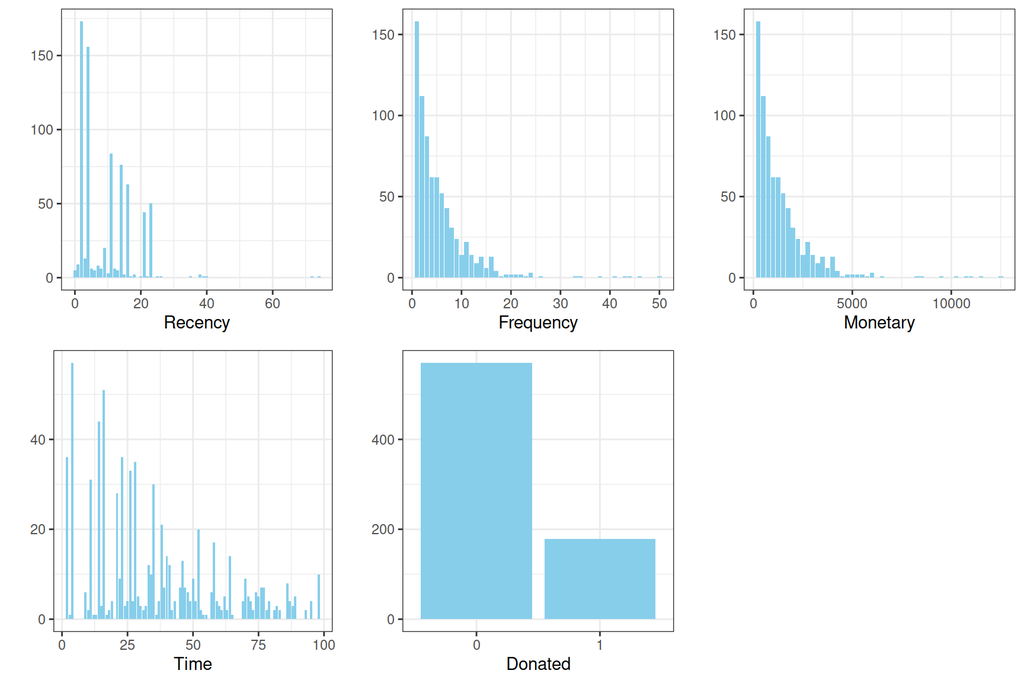

```r
library(ggplot2)
library(gridExtra)

variables <- names(blood)

plots <- lapply(variables, function(variable){
  ggplot(data=blood, aes_string(variable)) +
    geom_bar(fill='skyblue') +
    ylab('') +
    theme_bw()
})

grid.arrange(grobs=plots, ncol=3)
```

Na wykresach widać co najmniej dwie istotne kwestie:

- rozkłady zmiennych Frequency (całkowita liczba donacji) i Monetary (całkowita ilość oddanej krwi) są identyczne z dokładnością do skali (co prowdopodobnie wynika z faktu, że za każdym razem oddawana jest ta sama ilość krwi),
- rozkład zmiennej celu (Donated) nie jest równomierny.

## Przygotowanie modelu

W celu wykonania zadania posłużę się lasem losowym z domyślnymi parametrami.

```r
library(mlr)
library(PRROC)

classif_task <- makeClassifTask(id='blood', data=blood, target = "Donated")
classif_lrn <- makeLearner("classif.ranger", predict.type="prob")

model <- train(classif_lrn, classif_task)

pred <- predict(model, classif_task)$data$prob.1

fg <- pred[blood$Donated==1]
bg <- pred[blood$Donated==0]

roc <- roc.curve(scores.class0=fg, scores.class1=bg, curve=T)
pr <- pr.curve(scores.class0=fg, scores.class1=bg, curve=T)
```

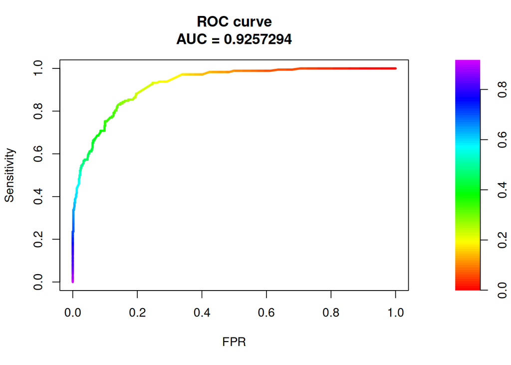

```r
plot(roc)
```

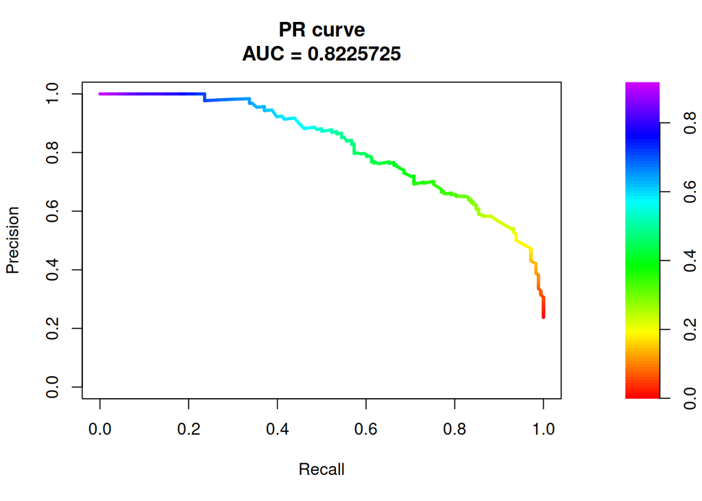

```r
plot(pr)
```

Model jest wystarczająco dobry na potrzeby tego zadania. Należy pamiętać, że zbiór nie został podzielony na podzbiór treningowy i testowy.

## Break Down i Shapley

Stwórzmy najpierw instancję explainera.

```r
library(DALEX)
library(DALEXtra)
explainer <- explain(model=model, data=blood, y=as.numeric(blood$Donated), label='mlr.ranger')
```

```
## Preparation of a new explainer is initiated
##   -> model label       :  mlr.ranger
##   -> data              :  748  rows  5  cols
##   -> target variable   :  748  values
##   -> predict function  :  yhat.WrappedModel  will be used (  default  )
##   -> predicted values  :  No value for predict function target column. (  default  )
##   -> model_info        :  package mlr , ver. 2.19.0 , task classification (  default  )
##   -> predicted values  :  numerical, min =  0.003173363 , mean =  0.2399265 , max =  0.9134901
##   -> residual function :  difference between y and yhat (  default  )
##   -> residuals         :  numerical, min =  0.2930738 , mean =  0.9980414 , max =  1.940115
##   A new explainer has been created!
```

Poniżej znajdują się rozwiązania poszczególnych podpunktów pracy domowej.

“Dla wybranej obserwacji ze zbioru danych wylicz predykcję modelu.”

```r
obs <- blood[13, ]
pred <- predict(model, newdata=obs)
pred$data
```

|  | truth | prob.0 | prob.1 | response |
| --- | --- | --- | --- | --- |
| 12 | 1 | 0.1313859 | 0.8686141 | 1 |

Model poprawnie przewidział odpowiedź dla obserwacji numer 12.

“Dla wybranej obserwacji z punktu 1., wylicz dekompozycję predykcji modelu używając SHAP, Break Down lub obie (pakiety w R: DALEX, iml, pakiety w Python: shap, dalex, piBreakDown).”

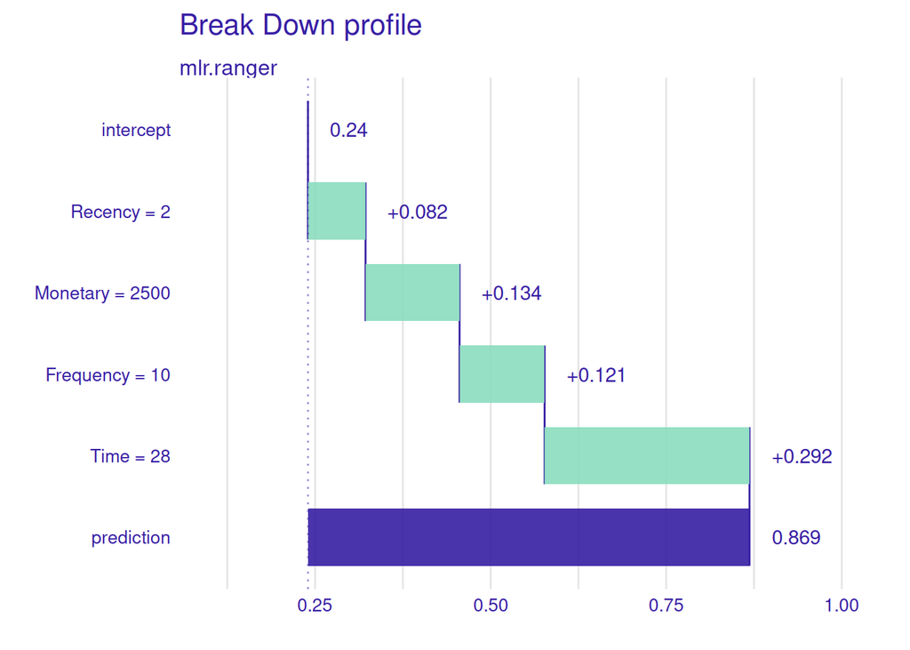

```r
bd12 <- predict_parts(explainer, new_observation=blood[13, 1:4])
plot(bd12)
```

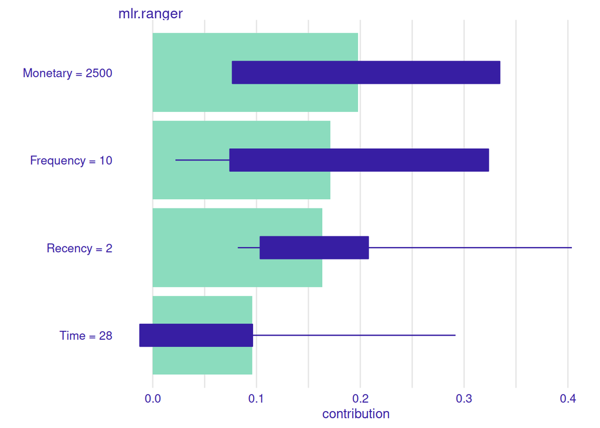

```r
sh12 <- predict_parts(explainer, new_observation=blood[13, 1:4], type="shap", B=24)
plot(sh12)
```

Wszystkie cechy osoby skrywającej się za obserwacją numer 12 wpływają korzystnie na prawdopodobnieństwo kolejnego oddania krwi - to, że oddawała ona krew zaledwie 2 miesiące temu, że oddała już 2500 jednostek w 10 donacjach oraz to, że oddaje ona krew już od ponad 2 lat (chociaż zgodnie z wykresem Shapley pozytywności tej cechy możemy być pewni najmniej).

“Wybierz dwie obserwacje ze zbioru danych, które mają inne najważniejsze zmienne (na przykład: dla obserwacji A ważne zmienne to wiek i płeć, a dla obserwacji B klasa i rasa).”

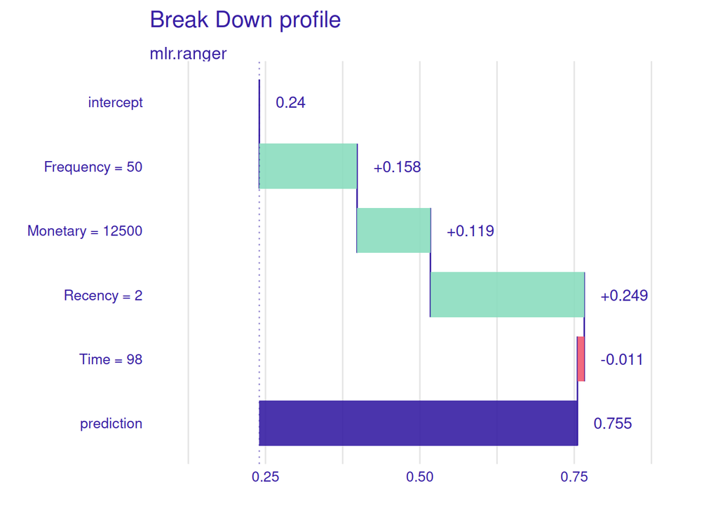

```r
bd0 <- predict_parts(explainer, new_observation=blood[1, 1:4])
plot(bd0)
```

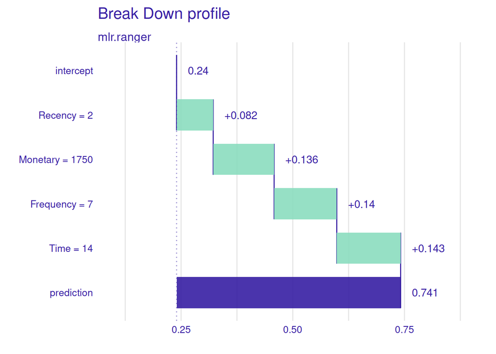

```r
bd6 <- predict_parts(explainer, new_observation=blood[7, 1:4])
plot(bd6)
```

Znajdź dwie obserwacje ze zbioru danych, które mają dla tych samych zmiennych inne efekty (pozytywny i negatywny)

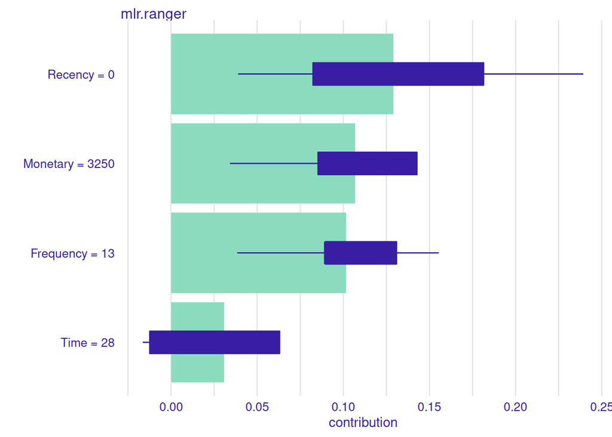

```r
sh1 <- predict_parts(explainer, new_observation=blood[2, 1:4], type="shap", B=24)
plot(sh1)
```

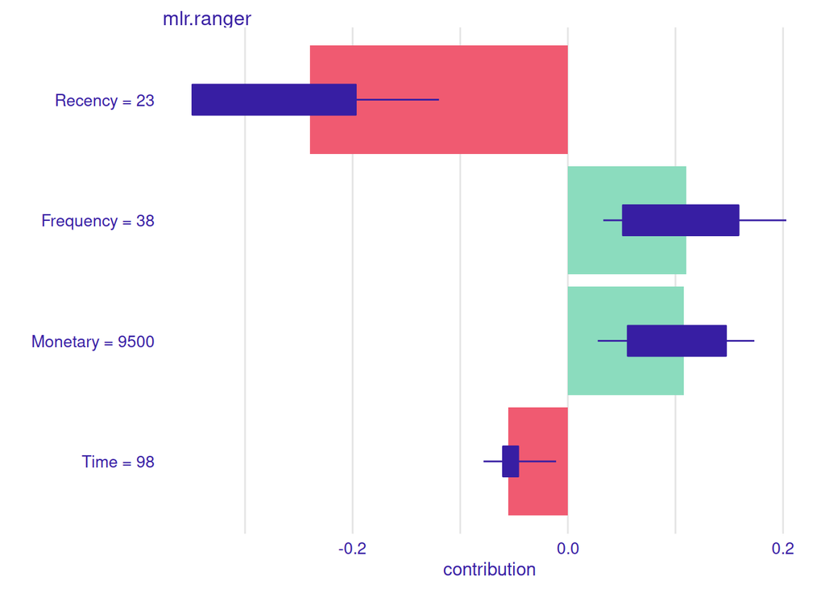

```r
sh341 <- predict_parts(explainer, new_observation=blood[342, 1:4], type="shap", B=24)
plot(sh341)
```

Fakt, że osoba spod obserwacji numer 1 oddawała krew jeszcze w tym miesiącu, wpływa zdecydowanie pozytywnie na szansę, że zrobi to ponownie. Z kolei dla osoby ukrytej pod obserwacją 341 widzimy, że nieoddawanie przez nią krwi od niemal dwóch lat ma skutek zdecydowanie przeciwny (choć w swoim czasie oddała ona znacznie więcej krwi, niż pierwsza osoba).